# Merge & Clean Summary

Alexander Cardazzi

```r
rev <- readRDS("C:/Users/alexc/Dropbox/glassdoor/data/cleaned/reviews_1.RDS")

rev$timestamp1 <- mdy(rev$timestamp1)
rev$stars <- as.numeric(rev$stars)
rev$company <- substr(rev$link, 1, regexpr("-Reviews", rev$link)-1)
WEIRD_SPACE <- substr(rev$title_location[2], 1, 1)
rev$title_location <- gsub(WEIRD_SPACE, " ", rev$title_location)
```

After scraping, below is the first row of the data so you can imagine what I am working with.

```r
t(rev[1,])
```

```
##                1
## title          "It's a good place to start your career, but not to grow it."
## stars          "2"
## other_stars    "Work/Life Balance:★★★★★;Culture & Values:★★★★★;Career Opportunities:★★★★★;Compensation and Benefits:★★★★★;Senior Management:★★★★★;"
## title_location "Former Employee - Anonymous Employee in Carle Place, NY"
## recommend      "Doesn't Recommend;Neutral Outlook;No opinion of CEO"
## type           "I worked at 1-800-Flowers.com full-time for more than 3 years"
## pro            "The company still runs like a mom and pop business, so you get to see a lot of different aspects of the business no matter what your position is."
## con            "There is zero work/life balance.  You are forced to work weekends and 12-15 hour days for several weeks leading up to peak times with no additional compensation, monetary or otherwise..  If you aren't part of the \"good old boys\" club, you will not get promoted."
## helpful        "Helpful (3)"
## link           "1-800-Flowers-com-Reviews-E4117_P10.html"
## timestamp1     "2015-01-06"
## timestamp2     "Tue Jan 06 2015 09:47:54 GMT-0800 (Pacific Standard Time)"
## company        "1-800-Flowers-com"
```

### Reviews

The first thing that might be important to visualize would be the number of reviews, in total, by day. This plot is quite busy, but it does a good job showing the overall trend in the frequency of reviews. I'd like to highlight the pandemic. I saw this shape when I made previous plots for Apple and American Express, but this is really interesting. The severe increase in reviews happens in August 2020, not March. The rest of the temporal plots will collapse these data to the month level.

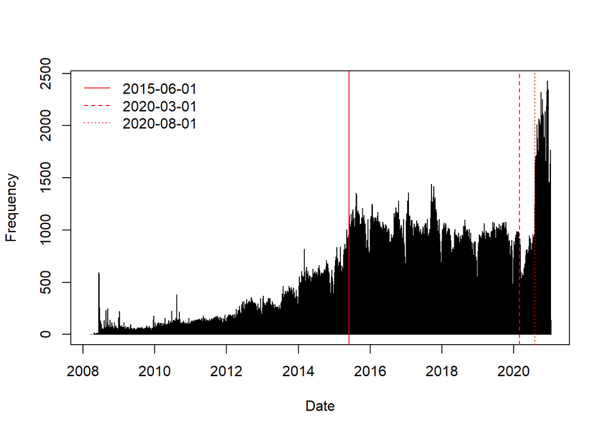

```r
t0 <- as.data.frame(table(rev$timestamp1))
plot(ymd(as.character(t0$Var1)), t0$Freq, type = "h", ylab = "Frequency", xlab = "Date")
abline(v = ymd(c("2015-06-01", "2020-03-01", "2020-08-01")), col = "red", lty = 1:3)
legend("topleft", legend = c("2015-06-01", "2020-03-01", "2020-08-01"), lty = 1:3, col= "red", bty = "n")
```

The next thing I looked at was the average rating by month. Here, we see a general upward trend in ratings. Perhaps this is due to the nature of the site. In the early stages of the site, perhaps you are more likely to post if you want to gripe. However, as it becomes more popular, you see more people reviewing for any reason. Just a hunch. At the same time, we were coming out of a recession in the early 2010s, so maybe that has some influence as well. I also highlighted the pandemic since I think this jump in average number of stars is quite interesting. I have not collected any of the *COVID* tags, but we can do this for another project if we want.

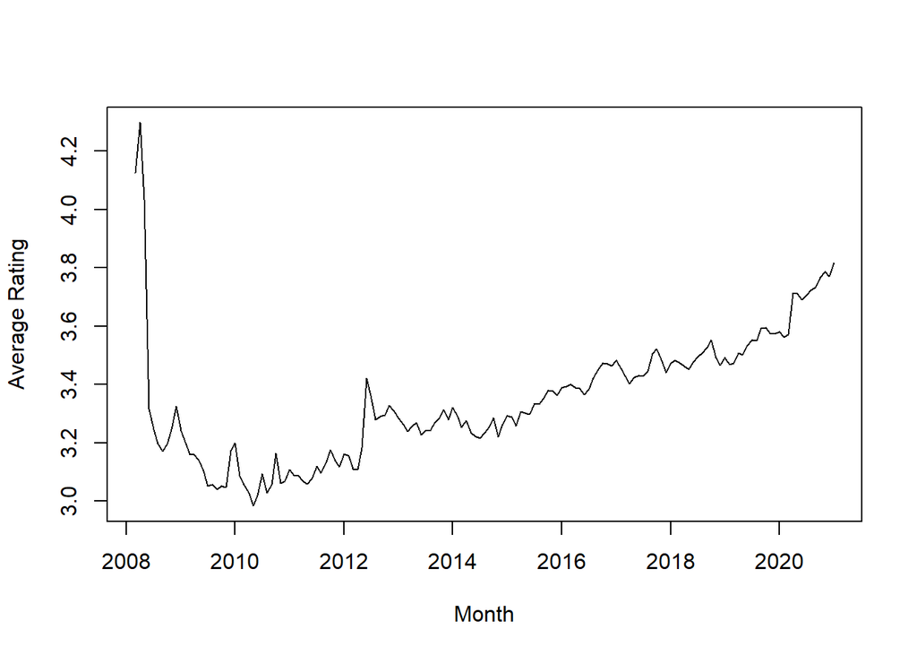

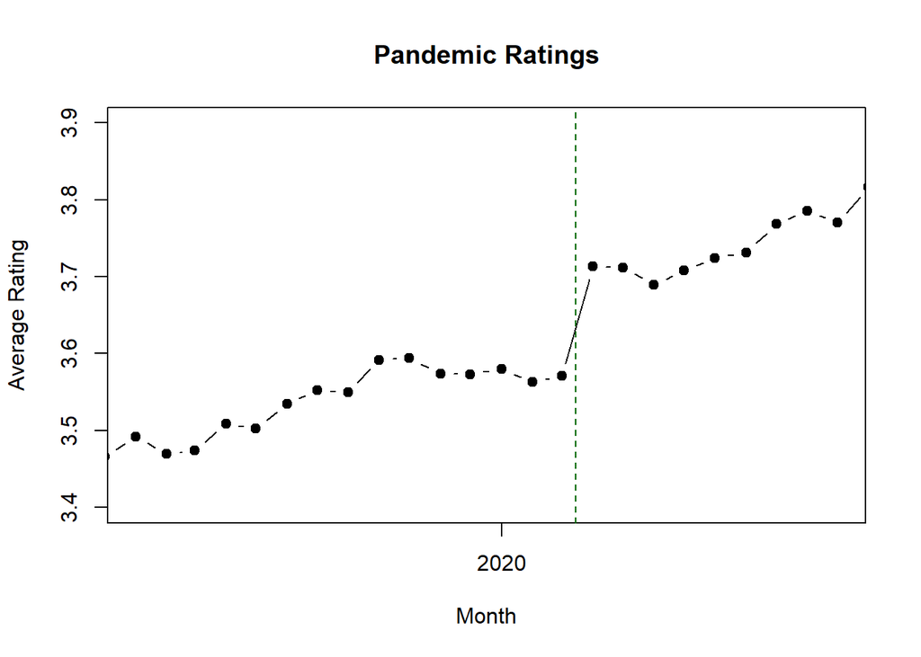

```r
t1 <- aggregate(rev$stars, list(floor_date(rev$timestamp1, "month")), mean, na.rm = TRUE)
plot(t1$Group.1, t1$x, type = "l", xlab = "Month", ylab = "Average Rating")
plot(t1$Group.1, t1$x, type = "b", pch = 19,
     xlim = ymd(c("2019-01-01", "2020-12-01")), ylim = c(3.4, 3.9),
     xlab = "Month", ylab = "Average Rating", main = "Pandemic Ratings")
abline(v = ymd("2020-03-15"), col = "dark green", lty = 2)
```

Another portion of the reviews is the dropdown. Reviewers can give their feedback overall as well as include specific information such as Work/Life Balance, Culture, Opportunities, etc. I have not cleaned these data up very much, but I did count the number of "Alternate" reviews left by each person, and tried to see if there were any patterns in how people left these. According to the first plot, the modal number of alternate reviews left is 6, but there are quite a few 0, 5 and 7. In the second plot, we see the average number of alt reviews by person by month. It appears that glassdoor was forcing users to fill out the 5 until they added category 6 and then 7. You can see when they added the categories by the third plot, which is the maximum number by month.

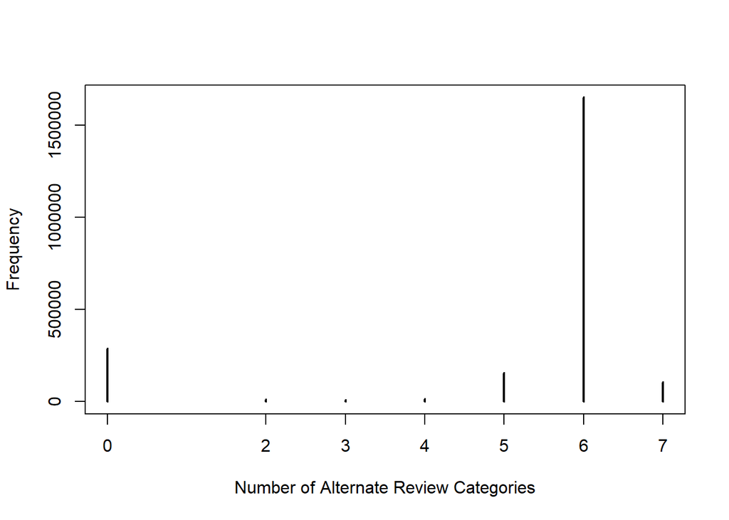

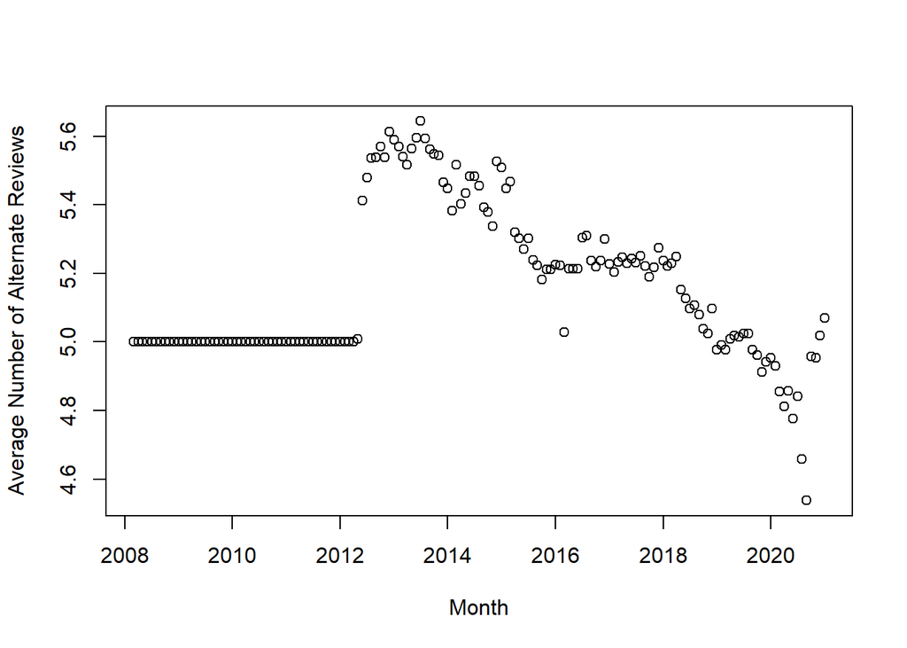

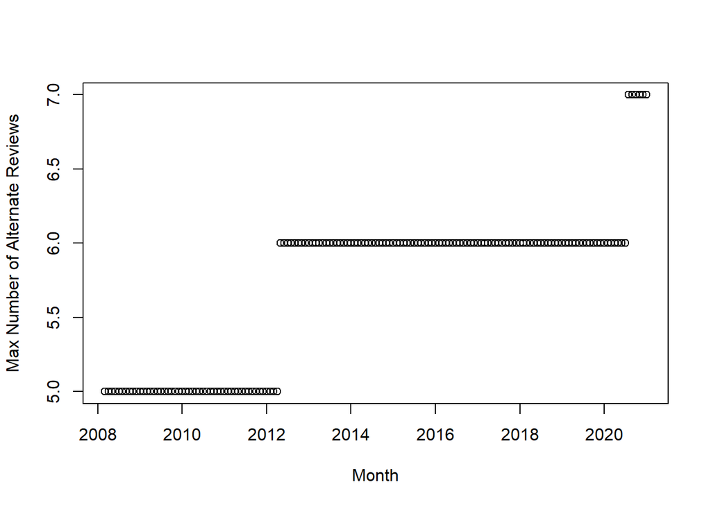

```r
other_rev <- ifelse(is.na(rev$other_stars), 0, nchar(rev$other_stars) - nchar(gsub(";", "", rev$other_stars)) + 1)
plot(table(other_rev), xlab = "Number of Alternate Review Categories", ylab = "Frequency")

t2 <- aggregate(other_rev, list(floor_date(rev$timestamp1, "month")), mean)
plot(t2$Group.1, t2$x, xlab = "Month", ylab = "Average Number of Alternate Reviews")

t2 <- aggregate(other_rev, list(floor_date(rev$timestamp1, "month")), max)
plot(t2$Group.1, t2$x, xlab = "Month", ylab = "Max Number of Alternate Reviews")
```

I plotted the distribution of ratings by company. This appears to be quite normally distributed which I found to be interesting.

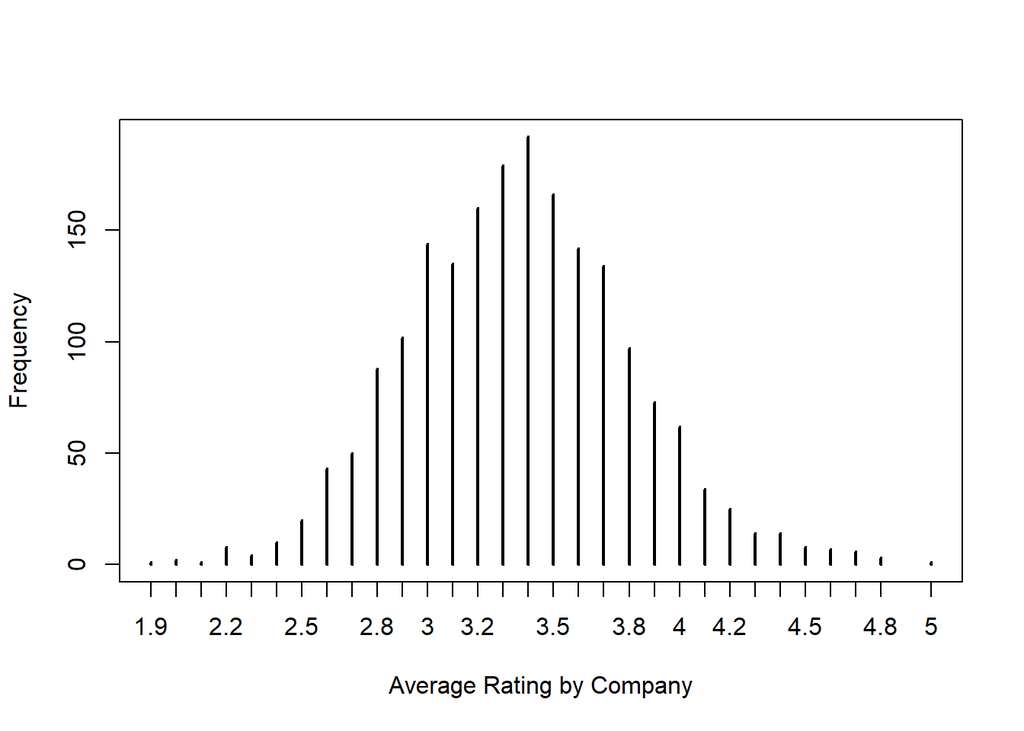

```r
t4 <- aggregate(rev$stars, list(rev$company), mean)
plot(table(round(t4$x, 1)), xlab = "Average Rating by Company", ylab = "Frequency")
```

Finally, I plotted the temporal distribution of the first and last date of each company's reviews.

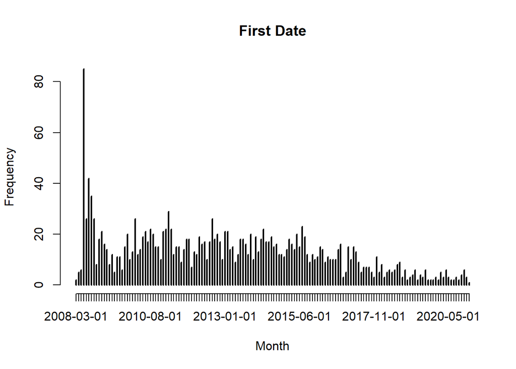

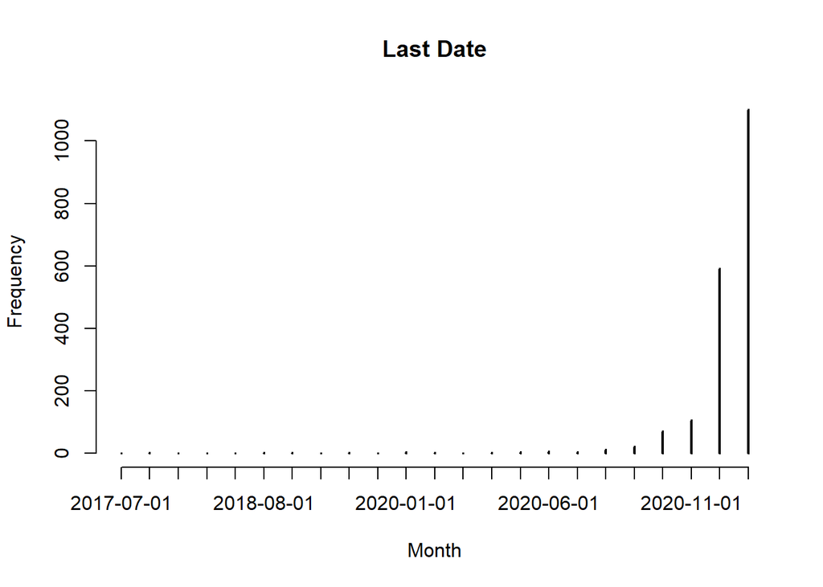

```r
t_min <- aggregate(floor_date(rev$timestamp1, "month"), list(rev$company), min)
t_max <- aggregate(floor_date(rev$timestamp1, "month"), list(rev$company), max)
plot(table(t_min$x), xlab = "Month", ylab = "Frequency", main = "First Date")
plot(table(t_max$x), xlab = "Month", ylab = "Frequency", main = "Last Date")
```

### Characteristics

I generated some basic tabulation of reviewer characteristics. For example, not all reviews had a location at all, let alone a US location. Some company pages would not show me non-US (meaning foreign or missing location) reviews but some would show everything. I tabulated this location information as a percent of all reviews. I did the same for whether a reviewer ultimately recommends a firm, and if the reviewer is a current or past employee.

```r
table(ifelse(grepl(" in ", rev$title_location), "Contains Location", "No Location")) * 100 / nrow(rev)
table(ifelse(grepl("^Doesn't", rev$recommend),
             "Does not Recommend",
             ifelse(grepl("^Recommends", rev$recommend), "Recommends", "Other"))) * 100 / nrow(rev)
table(ifelse(grepl("worked", rev$type), "Past", ifelse(grepl("working", rev$type), "Current", "Other"))) * 100 / nrow(rev)
```

```
##
## Contains Location       No Location
##          61.18593          38.81407
##
## Does not Recommend              Other         Recommends
##           28.29948           21.78930           49.91122
##
##      Current        Other         Past
## 5.498365e+01 7.588188e-04 4.501559e+01
```

### Text

I generate some distribution plot of number of characters in a few of the text boxes. While this does not ultimately tell us anything, it is still interesting to see. This first plot is the number of characters in the title of the review. There are a handful of review titles with insanely long titles, so I trimmmed the x-axis. There appears to be about a 120 character limit that somehow people were able to circumvent a few times. The modal title length looks to between 12 and 20 characters.

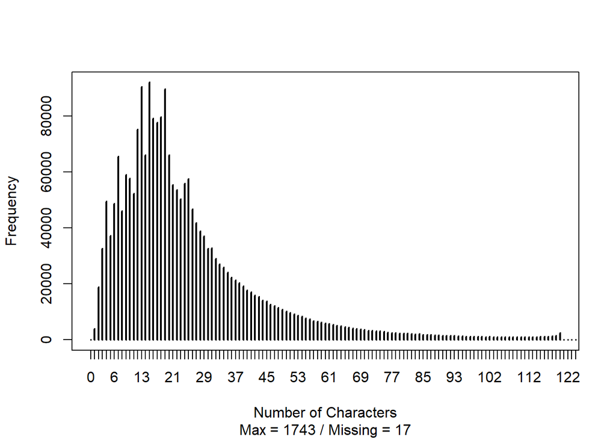

```r
plot(table(nchar(rev$title)), xlim = c(0, 120),
     ylab = "Frequency",
     xlab = c("Number of Characters", paste0("Max = ", max(nchar(rev$title), na.rm = TRUE), " / Missing = ", sum(is.na(nchar(rev$title))))))
```

I did a similar exercise for pro and con lengths. Key strokes for pros seem to be shorter while the distribution for cons has a fatter tail. I think the two-hump distribution is interesting as well. For example, there appears to be a modal value around 35 characters, but there seems to be another distribution with a mode of about 125. I imagine these in the "second" part of the distribution are 1 and 5 star reviews.

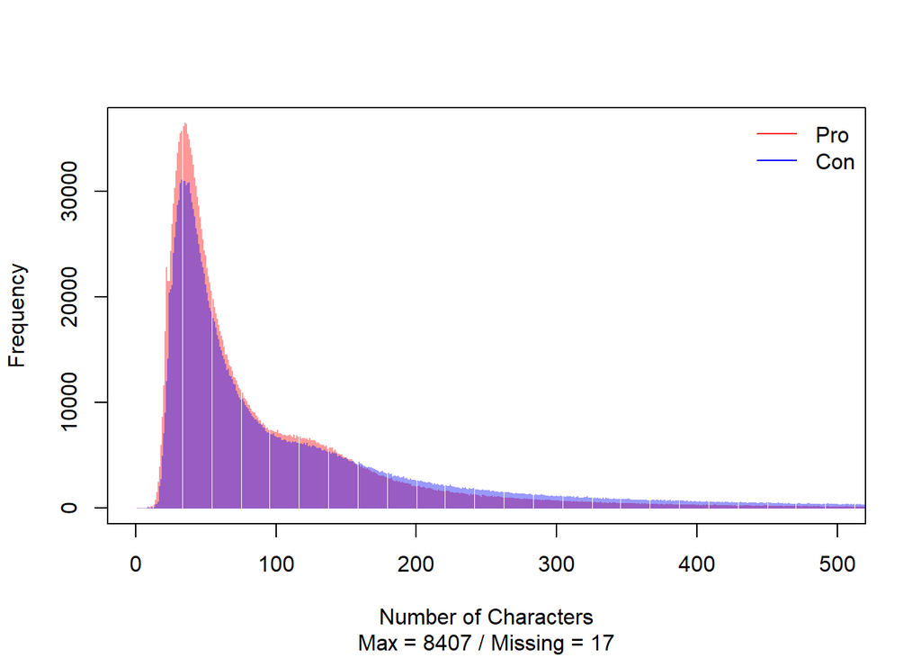

```r
t3 <- as.data.frame(table(nchar(rev$pro)))
plot(as.numeric(t3$Var1), t3$Freq, xlim = c(0, 500), type = "h",
     ylab = "Frequency",
     xlab = c("Number of Characters", paste0("Max = ", max(nchar(rev$pro), na.rm = TRUE), " / Missing = ", sum(is.na(nchar(rev$pro))))),
     col = alpha("red", .4))
t3 <- as.data.frame(table(nchar(rev$con)))
lines(as.numeric(t3$Var1), t3$Freq, xlim = c(0, 500), type = "h",
      col = alpha("blue", .4))
legend("topright", legend = c("Pro", "Con"), lty = 1, col = c("red", "blue"), bty = "n")
```

### Mergers and Aquisitions

I tried to figure out some information on what happens when company merge. According to [this](https://en.wikipedia.org/wiki/List_of_largest_mergers_and_acquisitions#2010s) wikipedia article, AT&T and Time Warner merged in 2016 and it was the 8th largest M&A of the 2010s. The string "Time Warner" is only found 59 times in the entire dataset. Something similar is the case for DirectTV too. At the same time, the second largest M&A was Dow and DuPont. Below is a plot of their average ratings.

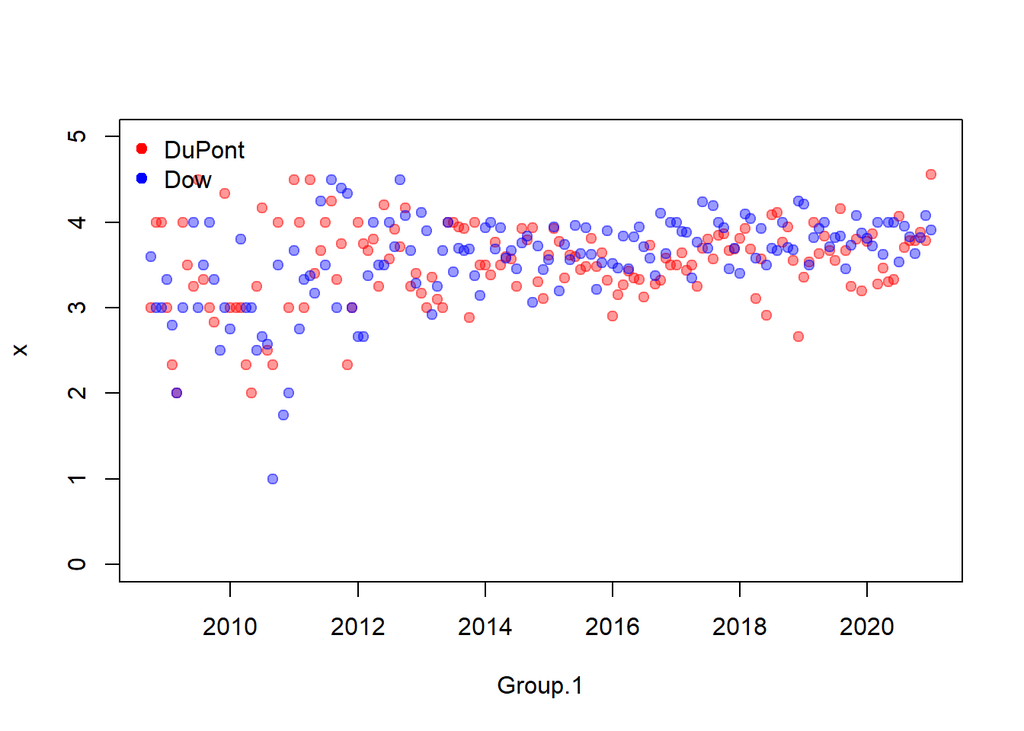

```r
rev2 <- rev[rev$company == "DuPont",]
plot(aggregate(rev2$stars, list(floor_date(rev2$timestamp1, "month")), mean), col = alpha("red", .4), pch = 19, ylim = c(0, 5))
rev2 <- rev[rev$company == "Dow",]
points(aggregate(rev2$stars, list(floor_date(rev2$timestamp1, "month")), mean), col = alpha("blue", .4), pch = 19)
legend("topleft", legend = c("DuPont", "Dow"), pch = 19, col = c("red", "blue"), bty = "n")
```

I also included a frequency plot and there is a spike in DuPont in 2016, but I am not sure what that is.

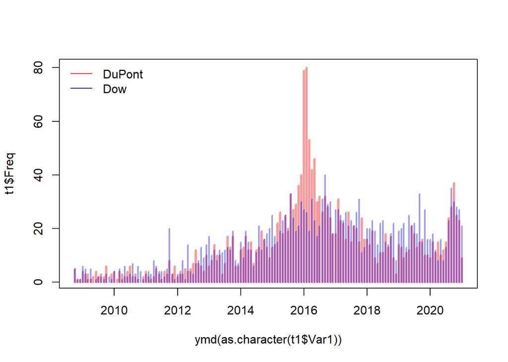

```r
rev2 <- rev[rev$company == "DuPont",]
t1 <- as.data.frame(table(floor_date(rev2$timestamp1, "month")))
rev2 <- rev[rev$company == "Dow",]
t2 <- as.data.frame(table(floor_date(rev2$timestamp1, "month")))
plot(ymd(as.character(t1$Var1)), t1$Freq, type = "h", col = alpha("red", .4), lwd = 3)
lines(ymd(as.character(t2$Var1)), t2$Freq, type = "h", col = alpha("blue", .4), lwd = 2)
legend("topleft", legend = c("DuPont", "Dow"), lty = 1, col = c("red", "blue"), bty = "n")
```

This did not immediately clear things up about M&A, but we can discuss this further. We also need to think about subsidiaries.